# Biomedical Data Quality-Control Case Study Using R and Bash

Author

Akash Bhardwaj

Published

July 16, 2026

## Project objective

This educational project demonstrates a simple, reproducible biomedical data quality-control workflow using Bash and R.

The workflow checks a small example patient-measurement dataset for duplicate patient identifiers and missing values, creates a cleaned dataset, produces descriptive summaries and visualisations, and performs an exploratory statistical comparison.

## Dataset

The project uses a small simulated dataset containing:

- Patient identifier
- Study group: Control or Treatment
- Age
- Biomarker measurement

The dataset was deliberately created with two data-quality issues:

- A duplicated patient identifier: `P006`
- A missing age value: `P005`

This is a simulated educational dataset. It contains no real patient information and must not be treated as clinical evidence.

## Bash quality-control checks

A Bash script was used to check that the input file exists, count data rows, identify duplicate patient IDs, and identify rows containing missing values.

The script found:

- Total data rows: 7
- Duplicate patient ID: `P006`
- Row containing a missing value: `P005,Control,,11.5`

The Bash output was saved as:

```
outputs/tables/qc_summary.txt
```

## R data quality checks and cleaning

The dataset was loaded into R for further inspection and cleaning.

The R workflow identified:

- One missing value in the `age` variable
- Two rows associated with the duplicated patient ID `P006`

Cleaning decisions:

1. Retained the first record for each unique patient identifier.
2. Removed the record with a missing age value.

### Cleaning summary

- Raw rows: 7
- Rows after retaining one record per patient ID: 6
- Rows after removing the missing-age record: 5

## Descriptive summary

After cleaning:

- Control group: 2 patients
- Treatment group: 3 patients
- Mean biomarker value in the Control group: 11.6
- Mean biomarker value in the Treatment group: 15.4

### Biomarker distribution by group

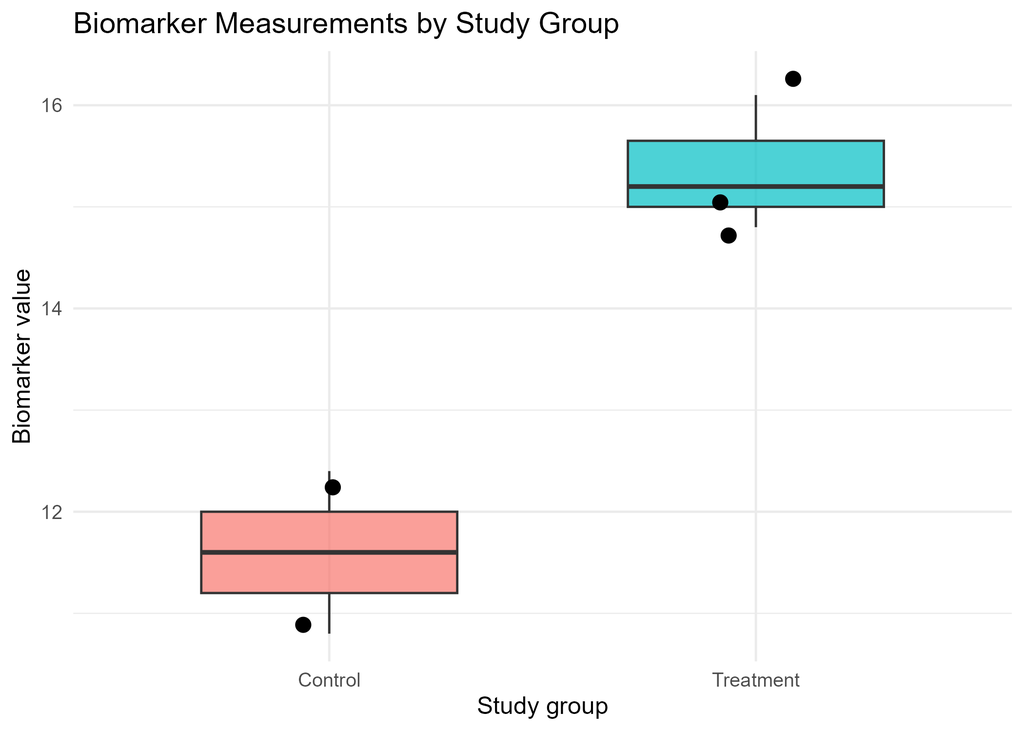

The figure is descriptive only. The sample size is too small to draw meaningful biomedical conclusions.

## Exploratory statistical comparison

A Welch two-sample t-test compared biomarker values between the cleaned Control and Treatment groups.

The confidence interval includes zero and the p-value is above 0.05. Therefore, this small demonstration dataset does not provide statistically significant evidence of a biomarker difference between groups.

## Reproducibility

The project workflow can be reproduced by running the scripts in the following order.

First, run the Bash quality-control script from the project root:

```bash
chmod +x scripts/qc_summary.sh
./scripts/qc_summary.sh
```

Then run the R scripts:

```
scripts/01_r_data_qc.R
scripts/02_biomarker_group_comparison.R
```

## Limitations

- This is a simulated educational dataset.
- The raw dataset contains only seven rows.
- The cleaned dataset contains only five records.
- The study groups contain only two and three observations.
- The statistical comparison is underpowered and included only to demonstrate the workflow.
- Real biomedical and clinical datasets require more extensive data-integrity, validation, privacy, and governance checks.

## Conclusion

This project demonstrates a basic quality-control workflow using Bash and R. It includes file checks, duplicate-ID detection, missing-value identification, data cleaning, descriptive summaries, visualisation, and an exploratory statistical comparison.

The project illustrates the importance of checking data quality before interpreting analytical results.